# Flanker MLM Trait Relationships

PD Inhibition Project

Michael Hallquist

5 Apr 2020

# Data cleaning and setup

```r
#flanker data processed in flanker_mlm.Rmd
#has the worst subjects removed, rt_inv transformation, etc.
load("../../Data/preprocessed/flanker_for_traits.RData")
```

## prepare for mplus

```r
prepareMplusData(flanker, filename="flanker_mplus.dat")
```

```
## Factors will be converted to numbers in Mplus data file
```

```
##
## Factor: cond
## Conversion:
##        level number
##    congruent      1
##  incongruent      2
##
## Factor: block
## Conversion:
##       level number
##  most_incon      1
##    most_con      2
```

```
## The file(s)
##  'flanker_mplus.dat'
## currently exist(s) and will be overwritten
```

```
## TITLE: Your title goes here
## DATA: FILE = "flanker_mplus.dat";
## VARIABLE:
## NAMES = id correct rt cond block trial block_number trial_z rt_inv run_trial
##      run_trial_z prev_rt prev_rt_inv exclude;
## MISSING=.;
```

# Initial model in Mplus

This model mimics m30 from flanker_mlms, though I did not try to accommodate heterogeneous variance at L1 (which is a pain).

I also haven’t validated it closely and should probably spend a little more time looking at the details.

```
m30 <-  lme(rt_inv ~ run_trial_z + trial_z + cond*block + prev_rt,
          random=list(id=~ 1 + run_trial_z + trial_z + cond + prev_rt, block=~1 + run_trial_z + trial_z),
          weights=varIdent(form=~1|block*cond),
          na.action = na.exclude,
          data = flanker, method='ML', control = lmeControl(opt="optim")) #lmeControl(maxIter = 200, msMaxIter = 200))
```

```r
m30_mplus <- mplusObject(
  TITLE = "Equivalent model to lme m30",
  DEFINE = "
    cond = cond - 1; ! 0=congruent, 1=incongruent
    block = block - 1; ! 0=most_incon, 1=most_con
    cond_block = cond*block; ! 1=most_con, incongruent
  ",
  VARIABLE = "
    WITHIN = cond block cond_block prev_rt trial_z run_trial_z;
    USEVARIABLES = id rt_inv cond block prev_rt trial_z run_trial_z cond_block;
    CLUSTER = id;
  ",
  ANALYSIS = "
    TYPE=TWOLEVEL RANDOM;
    ESTIMATOR=BAYES;
    FBITERATIONS=10000;
    CHAINS=2;
    PROCESSORS=4;
  ",
  MODEL = "
    %WITHIN%
    rt_inv ON block cond_block;
    condslo | rt_inv ON cond;
    runslo | rt_inv ON run_trial_z;
    trialslo | rt_inv ON trial_z;
    prevrtslo | rt_inv ON prev_rt;

    %BETWEEN%
    !means of random slopes
    [condslo];
    [runslo];
    [trialslo];
    [prevrtslo];

    !variances of random slopes
    condslo;
    runslo;
    trialslo;
    prevrtslo;

    !slope correlations
    condslo runslo trialslo prevrtslo WITH
       condslo runslo trialslo prevrtslo;

    [rt_inv]; !mean average inverse RT
  ",
  PLOT = "TYPE = PLOT2;",
  OUTPUT = "TECH1 TECH8 STANDARDIZED CINTERVAL;",
  rdata = flanker
)
```

```
## R variables selected automatically as any variable name that
## occurs in the MODEL, VARIABLE, or DEFINE section.
```

```
## The following variables are not unique in the first 8 characters:
##  run_trial_z
```

```r
mout <- mplusModeler(m30_mplus, dataout="flanker_mplus.dat",
                        modelout="m30_mplus.inp", run=TRUE)
```

```
## Wrote model to: m30_mplus.inp
```

```
## File(s) with md5 hash matching data found, using
## flanker_mplus_250251af597357c3fef01ad015d91a34.dat
```

```
##
## Running model: m30_mplus.inp
## System command: cd "." && "/Applications/Mplus/mplus" "m30_mplus.inp"
## Reading model:  m30_mplus.out
```

```r
results <- mout$results
```

Should run_trial_z and trial_z be WITHIN variables? Doesn’t seem like we care about the between component of these. For now, I have put them as WITHIN. But could revisit if there is any reason to anticipate a meaningful between-subjects latent variables for these.

## Unstandardized effects

```r
kable(results$parameters$unstandardized)
```

| paramHeader | param | est | posterior_sd | pval | lower_2.5ci | upper_2.5ci | sig | BetweenWithin |
| --- | --- | --- | --- | --- | --- | --- | --- | --- |
| RT_INV.ON | BLOCK | 0.011 | 0.009 | 0.118 | -0.007 | 0.029 | FALSE | Within |
| RT_INV.ON | COND_BLOCK | 0.055 | 0.013 | 0.000 | 0.028 | 0.081 | TRUE | Within |
| Residual.Variances | RT_INV | 0.149 | 0.002 | 0.000 | 0.146 | 0.152 | TRUE | Within |
| CONDSLO.WITH | RUNSLO | 0.000 | 0.000 | 0.408 | -0.001 | 0.001 | FALSE | Between |
| CONDSLO.WITH | TRIALSLO | -0.001 | 0.001 | 0.033 | -0.003 | 0.000 | FALSE | Between |
| CONDSLO.WITH | PREVRTSLO | -0.004 | 0.005 | 0.211 | -0.015 | 0.006 | FALSE | Between |
| RUNSLO.WITH | TRIALSLO | 0.000 | 0.000 | 0.458 | -0.001 | 0.001 | FALSE | Between |
| RUNSLO.WITH | PREVRTSLO | 0.000 | 0.002 | 0.449 | -0.005 | 0.005 | FALSE | Between |
| TRIALSLO.WITH | PREVRTSLO | 0.001 | 0.004 | 0.375 | -0.007 | 0.010 | FALSE | Between |
| Means | RT_INV | -3.377 | 0.034 | 0.000 | -3.443 | -3.311 | TRUE | Between |
| Means | CONDSLO | 0.113 | 0.011 | 0.000 | 0.091 | 0.135 | TRUE | Between |
| Means | RUNSLO | -0.002 | 0.004 | 0.291 | -0.011 | 0.006 | FALSE | Between |
| Means | TRIALSLO | -0.022 | 0.007 | 0.001 | -0.036 | -0.008 | TRUE | Between |
| Means | PREVRTSLO | 1.642 | 0.063 | 0.000 | 1.517 | 1.764 | TRUE | Between |
| Variances | RT_INV | 0.076 | 0.014 | 0.000 | 0.054 | 0.109 | TRUE | Between |
| Variances | CONDSLO | 0.004 | 0.001 | 0.000 | 0.002 | 0.007 | TRUE | Between |
| Variances | RUNSLO | 0.001 | 0.000 | 0.000 | 0.001 | 0.002 | TRUE | Between |
| Variances | TRIALSLO | 0.004 | 0.001 | 0.000 | 0.003 | 0.006 | TRUE | Between |
| Variances | PREVRTSLO | 0.162 | 0.043 | 0.000 | 0.096 | 0.265 | TRUE | Between |

## Standardized effects

```r
kable(results$parameters$stdyx)
```

| paramHeader | param | est | posterior_sd | pval | lower_2.5ci | upper_2.5ci | sig | BetweenWithin |
| --- | --- | --- | --- | --- | --- | --- | --- | --- |
| CONDSLO\|RT_INV.ON | COND | 0.133 | 0.011 | 0.000 | 0.112 | 0.156 | TRUE | Within.Std.Averaged.Over.Clusters |
| RUNSLO\|RT_INV.ON | RUN_TRIAL_ | -0.006 | 0.007 | 0.215 | -0.021 | 0.009 | FALSE | Within.Std.Averaged.Over.Clusters |
| TRIALSLO\|RT_INV.ON | TRIAL_Z | -0.049 | 0.007 | 0.000 | -0.063 | -0.034 | TRUE | Within.Std.Averaged.Over.Clusters |
| PREVRTSLO\|RT_INV.ON | PREV_RT | 0.256 | 0.007 | 0.000 | 0.243 | 0.269 | TRUE | Within.Std.Averaged.Over.Clusters |
| RT_INV.ON | BLOCK | 0.012 | 0.011 | 0.130 | -0.008 | 0.036 | FALSE | Within.Std.Averaged.Over.Clusters |
| RT_INV.ON | COND_BLOCK | 0.048 | 0.011 | 0.000 | 0.024 | 0.069 | TRUE | Within.Std.Averaged.Over.Clusters |
| Residual.Variances | RT_INV | 0.849 | 0.005 | 0.000 | 0.840 | 0.858 | TRUE | Within.Std.Averaged.Over.Clusters |
| CONDSLO.WITH | RUNSLO | 0.045 | 0.185 | 0.408 | -0.318 | 0.401 | FALSE | Between |
| CONDSLO.WITH | TRIALSLO | -0.286 | 0.147 | 0.033 | -0.556 | 0.019 | FALSE | Between |
| CONDSLO.WITH | PREVRTSLO | -0.161 | 0.196 | 0.211 | -0.517 | 0.243 | FALSE | Between |
| RUNSLO.WITH | TRIALSLO | -0.018 | 0.161 | 0.458 | -0.329 | 0.298 | FALSE | Between |
| RUNSLO.WITH | PREVRTSLO | -0.024 | 0.187 | 0.449 | -0.389 | 0.335 | FALSE | Between |
| TRIALSLO.WITH | PREVRTSLO | 0.049 | 0.151 | 0.375 | -0.252 | 0.335 | FALSE | Between |
| Means | RT_INV | -12.226 | 1.104 | 0.000 | -14.528 | -10.207 | TRUE | Between |
| Means | CONDSLO | 1.735 | 0.304 | 0.000 | 1.231 | 2.423 | TRUE | Between |
| Means | RUNSLO | -0.076 | 0.141 | 0.291 | -0.349 | 0.190 | FALSE | Between |
| Means | TRIALSLO | -0.328 | 0.110 | 0.001 | -0.544 | -0.112 | TRUE | Between |
| Means | PREVRTSLO | 4.067 | 0.571 | 0.000 | 3.124 | 5.367 | TRUE | Between |
| Variances | RT_INV | 1.000 | 0.000 | 0.000 | 1.000 | 1.000 | FALSE | Between |
| Variances | CONDSLO | 1.000 | 0.000 | 0.000 | 1.000 | 1.000 | FALSE | Between |
| Variances | RUNSLO | 1.000 | 0.000 | 0.000 | 1.000 | 1.000 | FALSE | Between |
| Variances | TRIALSLO | 1.000 | 0.000 | 0.000 | 1.000 | 1.000 | FALSE | Between |
| Variances | PREVRTSLO | 1.000 | 0.000 | 0.000 | 1.000 | 1.000 | FALSE | Between |

## Summary

Although it’s a little more legwork to look for the right parameters since some show up as means (random slopes) and others as fixed effect parameters, there is a high degree of convergence between this output and m30.

# Trait overview

Just prototyping here… Get SNAP scores and try to build an antagonism factor.

```r
snap_scores <- read.sas7bdat("~/TresorSync/Grad_School/Dissertation/Analyses/Data/snap2scores.sas7bdat") %>%
  select(subject, starts_with("T_")) %>% dplyr::rename(id=subject)
```

## Quick EFA

Drop validity scales for a minute, as well as higher-order scales, look at spectrum

```r
to_efa <- snap_scores %>% select(-id, -T_InvalidityIndex, -T_RareVirtues, -T_Deviance, -T_BackDeviance, -T_TRIN, -T_VRIN, -T_DRIN,
                                 -T_NegativeTemperament, -T_PositiveTemperament, -T_Disinhibition, #higher-order scales
                                 -T_SuicideProneness, -T_LowSelfEsteem) #these have item overlap with self-harm
eigen(cor(to_efa))$values
```

```
##  [1] 3.119 2.216 1.893 1.138 0.830 0.588 0.527 0.436 0.375 0.362 0.263 0.254
```

### Correlation plot of 12 SNAP scales

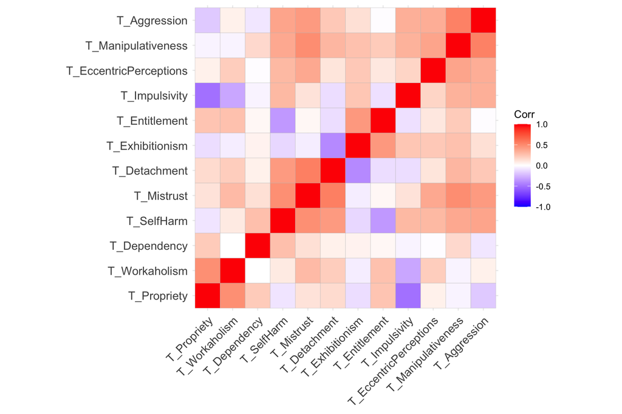

```r
ggcorrplot(to_efa %>% cor(), hc.order = TRUE)
```

### 4-factor EFA (Kaiser’s rule)

```r
fa4 <- fa(to_efa, nfactors = 4, fm="ml")
fa4
```

```
## Factor Analysis using method =  ml
## Call: fa(r = to_efa, nfactors = 4, fm = "ml")
## Standardized loadings (pattern matrix) based upon correlation matrix
##                          ML4   ML3   ML2   ML1   h2    u2 com
## T_Mistrust              0.67  0.14 -0.13  0.16 0.60 0.396 1.3
## T_Manipulativeness      0.72 -0.11  0.21  0.06 0.63 0.371 1.2
## T_Aggression            0.59 -0.25  0.07  0.09 0.46 0.536 1.4
## T_SelfHarm              0.06  0.01 -0.01  0.97 1.00 0.005 1.0
## T_EccentricPerceptions  0.36  0.08  0.27  0.20 0.29 0.708 2.6
## T_Dependency           -0.13  0.28  0.19  0.41 0.17 0.832 2.5
## T_Exhibitionism         0.05 -0.04  0.81  0.00 0.68 0.321 1.0
## T_Entitlement           0.28  0.33  0.47 -0.34 0.54 0.459 3.5
## T_Detachment            0.56  0.14 -0.54  0.08 0.66 0.336 2.2
## T_Impulsivity           0.20 -0.59  0.23  0.17 0.53 0.467 1.8
## T_Propriety            -0.03  0.80  0.03  0.03 0.62 0.379 1.0
## T_Workaholism           0.11  0.62  0.04  0.12 0.40 0.597 1.2
##
##                        ML4  ML3  ML2  ML1
## SS loadings           2.04 1.67 1.41 1.48
## Proportion Var        0.17 0.14 0.12 0.12
## Cumulative Var        0.17 0.31 0.43 0.55
## Proportion Explained  0.31 0.25 0.21 0.22
## Cumulative Proportion 0.31 0.56 0.78 1.00
##
##  With factor correlations of
##      ML4   ML3   ML2   ML1
## ML4 1.00  0.07  0.08  0.42
## ML3 0.07  1.00 -0.12 -0.14
## ML2 0.08 -0.12  1.00 -0.20
## ML1 0.42 -0.14 -0.20  1.00
##
## Mean item complexity =  1.7
## Test of the hypothesis that 4 factors are sufficient.
##
## The degrees of freedom for the null model are  66  and the objective function was  4.19 with Chi Square of  441
## The degrees of freedom for the model are 24  and the objective function was  0.39
##
## The root mean square of the residuals (RMSR) is  0.04
## The df corrected root mean square of the residuals is  0.07
##
## The harmonic number of observations is  111 with the empirical chi square  27.5  with prob <  0.28
## The total number of observations was  111  with Likelihood Chi Square =  39.9  with prob <  0.022
##
## Tucker Lewis Index of factoring reliability =  0.88
## RMSEA index =  0.077  and the 90 % confidence intervals are  0.03 0.119
## BIC =  -73.1
## Fit based upon off diagonal values = 0.97
## Measures of factor score adequacy
##                                                    ML4  ML3  ML2  ML1
## Correlation of (regression) scores with factors   0.91 0.89 0.89 1.00
## Multiple R square of scores with factors          0.83 0.79 0.80 0.99
## Minimum correlation of possible factor scores     0.66 0.58 0.60 0.99
```

### 3-factor EFA

Self-harm likes to stay to itself. Reduce to 3-factor solution

```r
fa3 <- fa(to_efa, nfactors = 3, fm="ml")
fa3
```

```
## Factor Analysis using method =  ml
## Call: fa(r = to_efa, nfactors = 3, fm = "ml")
## Standardized loadings (pattern matrix) based upon correlation matrix
##                         ML1   ML2   ML3    h2   u2 com
## T_Mistrust             0.78  0.17 -0.03 0.636 0.36 1.1
## T_Manipulativeness     0.69 -0.12  0.32 0.605 0.39 1.5
## T_Aggression           0.61 -0.24  0.13 0.456 0.54 1.4
## T_SelfHarm             0.65 -0.19 -0.29 0.548 0.45 1.6
## T_EccentricPerceptions 0.48  0.00  0.25 0.289 0.71 1.5
## T_Dependency           0.16  0.12  0.02 0.039 0.96 1.9
## T_Exhibitionism        0.00 -0.18  0.75 0.619 0.38 1.1
## T_Entitlement          0.02  0.37  0.69 0.578 0.42 1.5
## T_Detachment           0.60  0.26 -0.38 0.588 0.41 2.1
## T_Impulsivity          0.27 -0.67  0.14 0.558 0.44 1.4
## T_Propriety            0.05  0.74  0.08 0.548 0.45 1.0
## T_Workaholism          0.23  0.59  0.09 0.390 0.61 1.3
##
##                        ML1  ML2  ML3
## SS loadings           2.64 1.72 1.49
## Proportion Var        0.22 0.14 0.12
## Cumulative Var        0.22 0.36 0.49
## Proportion Explained  0.45 0.29 0.25
## Cumulative Proportion 0.45 0.75 1.00
##
##  With factor correlations of
##       ML1   ML2   ML3
## ML1  1.00 -0.03 -0.01
## ML2 -0.03  1.00 -0.07
## ML3 -0.01 -0.07  1.00
##
## Mean item complexity =  1.5
## Test of the hypothesis that 3 factors are sufficient.
##
## The degrees of freedom for the null model are  66  and the objective function was  4.19 with Chi Square of  441
## The degrees of freedom for the model are 33  and the objective function was  0.66
##
## The root mean square of the residuals (RMSR) is  0.06
## The df corrected root mean square of the residuals is  0.08
##
## The harmonic number of observations is  111 with the empirical chi square  45.6  with prob <  0.071
## The total number of observations was  111  with Likelihood Chi Square =  68.5  with prob <  0.00028
##
## Tucker Lewis Index of factoring reliability =  0.807
## RMSEA index =  0.098  and the 90 % confidence intervals are  0.065 0.132
## BIC =  -87
## Fit based upon off diagonal values = 0.96
## Measures of factor score adequacy
##                                                    ML1  ML2  ML3
## Correlation of (regression) scores with factors   0.93 0.89 0.89
## Multiple R square of scores with factors          0.86 0.79 0.78
## Minimum correlation of possible factor scores     0.72 0.57 0.57
```

### Simple antagonism factor

Try 1-factor model with Mistrust, Manipulativeness, Aggression, and Self-Harm

Detachment is squirrelly

```r
pathology1 <- "
 f =~ T_Mistrust + T_Manipulativeness + T_Aggression + T_SelfHarm # + T_Detachment
"

m1 <- cfa(pathology1, data=snap_scores, estimator="MLR")
summary(m1, fit.measures=TRUE, standardized=TRUE)
```

```
## lavaan 0.6-5 ended normally after 47 iterations
##
##   Estimator                                         ML
##   Optimization method                           NLMINB
##   Number of free parameters                          8
##
##   Number of observations                           111
##
## Model Test User Model:
##                                               Standard      Robust
##   Test Statistic                                 4.905       3.117
##   Degrees of freedom                                 2           2
##   P-value (Chi-square)                           0.086       0.210
##   Scaling correction factor                                  1.574
##     for the Yuan-Bentler correction (Mplus variant)
##
## Model Test Baseline Model:
##
##   Test statistic                               111.007      79.754
##   Degrees of freedom                                 6           6
##   P-value                                        0.000       0.000
##   Scaling correction factor                                  1.392
##
## User Model versus Baseline Model:
##
##   Comparative Fit Index (CFI)                    0.972       0.985
##   Tucker-Lewis Index (TLI)                       0.917       0.955
##
##   Robust Comparative Fit Index (CFI)                         0.983
##   Robust Tucker-Lewis Index (TLI)                            0.949
##
## Loglikelihood and Information Criteria:
##
##   Loglikelihood user model (H0)              -1659.543   -1659.543
##   Scaling correction factor                                  1.375
##       for the MLR correction
##   Loglikelihood unrestricted model (H1)      -1657.090   -1657.090
##   Scaling correction factor                                  1.415
##       for the MLR correction
##
```

[output cut: 25 more lines]

```
## Latent Variables:
##                    Estimate  Std.Err  z-value  P(>|z|)   Std.lv  Std.all
##   f =~
##     T_Mistrust        1.000                               7.338    0.686
##     T_Manipultvnss    1.159    0.255    4.545    0.000    8.503    0.721
##     T_Aggression      1.058    0.241    4.398    0.000    7.766    0.688
##     T_SelfHarm        0.971    0.181    5.352    0.000    7.123    0.589
##
## Variances:
##                    Estimate  Std.Err  z-value  P(>|z|)   Std.lv  Std.all
##    .T_Mistrust       60.571   11.496    5.269    0.000   60.571    0.529
##    .T_Manipultvnss   66.656   14.274    4.670    0.000   66.656    0.480
##    .T_Aggression     66.993   20.166    3.322    0.001   66.993    0.526
##    .T_SelfHarm       95.535   17.310    5.519    0.000   95.535    0.653
##     f                53.850   17.876    3.012    0.003    1.000    1.000
```

```r
modificationindices(m1, minimum.value = 4)
```

```
##                   lhs op          rhs  mi  epc sepc.lv sepc.all sepc.nox
## 12         T_Mistrust ~~   T_SelfHarm 4.5 22.7    22.7    0.299    0.299
## 13 T_Manipulativeness ~~ T_Aggression 4.5 28.7    28.7    0.430    0.430
```

# Trait - flanker MSEM prototype

Add relevant SNAP scores to Mplus dataset, then fit MSEM model with traits as moderator of congruency random slope

```r
flanker_traits <- full_join(snap_scores %>% select(id, T_Mistrust, T_Manipulativeness, T_Aggression, T_SelfHarm),
                            flanker, by="id")
```

## Corroborate 1-factor model in simple between-subjects Mplus

```r
mplus_trait <- mplusObject(
  TITLE = "Antagonismesque factor",
  VARIABLE = "
    USEVARIABLES = T_Mistrust T_Manipulativeness T_Aggression T_SelfHarm;
  ",
  ANALYSIS = "
    ESTIMATOR=BAYES;
    FBITERATIONS=10000;
    CHAINS=2;
    PROCESSORS=4;
  ",
  MODEL = "
    ! trait model
    antag BY T_Mistrust T_Manipulativeness T_Aggression T_SelfHarm;

  ",
  PLOT = "TYPE = PLOT2;",
  OUTPUT = "TECH1 TECH8 STANDARDIZED CINTERVAL;",
  rdata = snap_scores %>% select(id, T_Mistrust, T_Manipulativeness, T_Aggression, T_SelfHarm)
)
```

```
## R variables selected automatically as any variable name that
## occurs in the MODEL, VARIABLE, or DEFINE section.
```

```r
mout_trait <- mplusModeler(mplus_trait, dataout="traits_mplus.dat",
                        modelout="mplus_antag.inp", run=TRUE)
```

```
## Wrote model to: mplus_antag.inp
```

```
## File(s) with md5 hash matching data found, using
## traits_mplus_ac909afa2c8806c8d01dabbf80b5f562.dat
```

```
##
## Running model: mplus_antag.inp
## System command: cd "." && "/Applications/Mplus/mplus" "mplus_antag.inp"
## Reading model:  mplus_antag.out
```

```r
trait_antag <- mout_trait$results
```

### Unstandardized effects

```r
kable(trait_antag$parameters$unstandardized)
```

| paramHeader | param | est | posterior_sd | pval | lower_2.5ci | upper_2.5ci | sig |
| --- | --- | --- | --- | --- | --- | --- | --- |
| ANTAG.BY | T_MISTRUST | 1.000 | 0.000 | 0 | 1.000 | 1.00 | FALSE |
| ANTAG.BY | T_MANIPULA | 1.180 | 0.265 | 0 | 0.795 | 1.81 | TRUE |
| ANTAG.BY | T_AGGRESSI | 1.080 | 0.257 | 0 | 0.706 | 1.69 | TRUE |
| ANTAG.BY | T_SELFHARM | 0.988 | 0.228 | 0 | 0.632 | 1.53 | TRUE |
| Intercepts | T_MISTRUST | 53.447 | 1.037 | 0 | 51.401 | 55.44 | TRUE |
| Intercepts | T_MANIPULA | 57.635 | 1.145 | 0 | 55.362 | 59.84 | TRUE |
| Intercepts | T_AGGRESSI | 52.990 | 1.093 | 0 | 50.784 | 55.09 | TRUE |
| Intercepts | T_SELFHARM | 52.149 | 1.180 | 0 | 49.841 | 54.46 | TRUE |
| Variances | ANTAG | 52.690 | 17.050 | 0 | 24.835 | 92.05 | TRUE |
| Residual.Variances | T_MISTRUST | 64.585 | 13.463 | 0 | 40.983 | 94.05 | TRUE |
| Residual.Variances | T_MANIPULA | 71.244 | 15.791 | 0 | 42.714 | 105.24 | TRUE |
| Residual.Variances | T_AGGRESSI | 70.561 | 14.436 | 0 | 45.285 | 101.76 | TRUE |
| Residual.Variances | T_SELFHARM | 100.430 | 17.408 | 0 | 71.119 | 138.89 | TRUE |

### Standardized effects

```r
kable(trait_antag$parameters$stdyx)
```

| paramHeader | param | est | posterior_sd | pval | lower_2.5ci | upper_2.5ci | sig |
| --- | --- | --- | --- | --- | --- | --- | --- |
| ANTAG.BY | T_MISTRUST | 0.670 | 0.084 | 0 | 0.485 | 0.813 | TRUE |
| ANTAG.BY | T_MANIPULA | 0.713 | 0.075 | 0 | 0.549 | 0.843 | TRUE |
| ANTAG.BY | T_AGGRESSI | 0.683 | 0.077 | 0 | 0.513 | 0.812 | TRUE |
| ANTAG.BY | T_SELFHARM | 0.582 | 0.085 | 0 | 0.394 | 0.728 | TRUE |
| Intercepts | T_MISTRUST | 4.914 | 0.350 | 0 | 4.260 | 5.627 | TRUE |
| Intercepts | T_MANIPULA | 4.776 | 0.338 | 0 | 4.142 | 5.479 | TRUE |
| Intercepts | T_AGGRESSI | 4.593 | 0.327 | 0 | 3.979 | 5.254 | TRUE |
| Intercepts | T_SELFHARM | 4.216 | 0.303 | 0 | 3.633 | 4.823 | TRUE |
| Variances | ANTAG | 1.000 | 0.000 | 0 | 1.000 | 1.000 | FALSE |
| Residual.Variances | T_MISTRUST | 0.551 | 0.109 | 0 | 0.340 | 0.765 | TRUE |
| Residual.Variances | T_MANIPULA | 0.492 | 0.105 | 0 | 0.290 | 0.699 | TRUE |
| Residual.Variances | T_AGGRESSI | 0.533 | 0.102 | 0 | 0.340 | 0.737 | TRUE |
| Residual.Variances | T_SELFHARM | 0.661 | 0.096 | 0 | 0.470 | 0.845 | TRUE |

Looks very clean – not perfect (RMSEA) – and comparable to lavaan

## Full MSEM with Antagonism as predictor (moderator) of random slopes

```r
m30_mplus_trait <- mplusObject(
  TITLE = "Antagonismesque factor and flanker",
  DEFINE = "
    cond = cond - 1; ! 0=congruent, 1=incongruent
    block = block - 1; ! 0=most_incon, 1=most_con
    cond_block = cond*block; ! 1=most_con, incongruent
  ",
  VARIABLE = "
    WITHIN = cond block cond_block prev_rt trial_z run_trial_z;
    BETWEEN = T_Mistrust T_Manipulativeness T_Aggression T_SelfHarm;
    USEVARIABLES = id rt_inv cond block prev_rt trial_z run_trial_z
      T_Mistrust T_Manipulativeness T_Aggression T_SelfHarm cond_block;
    CLUSTER = id;
  ",
  ANALYSIS = "
    TYPE=TWOLEVEL RANDOM;
    ESTIMATOR=BAYES;
    FBITERATIONS=10000;
    CHAINS=2;
    PROCESSORS=4;
  ",
  MODEL = "
    %WITHIN%
    rt_inv ON block cond_block;
    condslo | rt_inv ON cond;
    runslo | rt_inv ON run_trial_z;
    trialslo | rt_inv ON trial_z;
    prevrtslo | rt_inv ON prev_rt;

    %BETWEEN%

    !means of random slopes
    [condslo];
    [runslo];
    [trialslo];
    [prevrtslo];

    !variances of random slopes
    condslo;
    runslo;
    trialslo;
    prevrtslo;

    !slope correlations (removed because all n.s.)
    !condslo runslo trialslo prevrtslo WITH
    !   condslo runslo trialslo prevrtslo;

    [rt_inv]; !mean average inverse RT

    ! trait model
    antag BY T_Mistrust T_Manipulativeness T_Aggression T_SelfHarm;

    ! trait moderates flanker performance -- incongruency effect and stickiness of RT
    condslo ON antag;
    prevrtslo ON antag;

    !N.B. Leaving out the association of antag with rt_inv omits a hugely important relationship
    !  on the between level and will lead to bizarre problems -- like factor loadings near zero

    !allow antag as a predictor of average RT
    rt_inv ON antag;

    ! let factor correlate with other variables on the between level
    ! omitting this for now because it leads to estimation problems at times and when added individually, these are highly n.s.
    !antag WITH runslo;
    !antag WITH trialslo;

  ",
  PLOT = "TYPE = PLOT2;",
  OUTPUT = "TECH1 TECH8 STANDARDIZED CINTERVAL;",
  rdata = flanker_traits
)
```

```
## R variables selected automatically as any variable name that
## occurs in the MODEL, VARIABLE, or DEFINE section.
```

```
## The following variables are not unique in the first 8 characters:
##  run_trial_z
```

```r
mout_antag <- mplusModeler(m30_mplus_trait, dataout="flanker_traits_mplus.dat",
                        modelout="m30_mplus_antag.inp", run=TRUE)
```

```
## Wrote model to: m30_mplus_antag.inp
```

```
## File(s) with md5 hash matching data found, using
## flanker_traits_mplus_acc9670d91dd3acb83a112c75a20acf1.dat
```

```
##
## Running model: m30_mplus_antag.inp
## System command: cd "." && "/Applications/Mplus/mplus" "m30_mplus_antag.inp"
## Reading model:  m30_mplus_antag.out
```

```r
results_antag <- mout_antag$results
```

### Unstandardized effects

```r
kable(results_antag$parameters$unstandardized)
```

| paramHeader | param | est | posterior_sd | pval | lower_2.5ci | upper_2.5ci | sig | BetweenWithin |
| --- | --- | --- | --- | --- | --- | --- | --- | --- |
| RT_INV.ON | BLOCK | 0.012 | 0.009 | 0.102 | -0.007 | 0.030 | FALSE | Within |
| RT_INV.ON | COND_BLOCK | 0.054 | 0.013 | 0.000 | 0.029 | 0.080 | TRUE | Within |
| Residual.Variances | RT_INV | 0.149 | 0.002 | 0.000 | 0.146 | 0.152 | TRUE | Within |
| ANTAG.BY | T_MISTRUST | 1.000 | 0.000 | 0.000 | 1.000 | 1.000 | FALSE | Between |
| ANTAG.BY | T_MANIPULA | 1.274 | 0.314 | 0.000 | 0.829 | 2.045 | TRUE | Between |
| ANTAG.BY | T_AGGRESSI | 1.112 | 0.286 | 0.000 | 0.709 | 1.824 | TRUE | Between |
| ANTAG.BY | T_SELFHARM | 1.018 | 0.265 | 0.000 | 0.610 | 1.642 | TRUE | Between |
| CONDSLO.ON | ANTAG | 0.003 | 0.002 | 0.011 | 0.000 | 0.007 | TRUE | Between |
| PREVRTSLO.ON | ANTAG | 0.031 | 0.017 | 0.009 | 0.005 | 0.070 | TRUE | Between |
| RT_INV.ON | ANTAG | -0.022 | 0.010 | 0.001 | -0.045 | -0.008 | TRUE | Between |
| Means | RUNSLO | -0.002 | 0.004 | 0.290 | -0.011 | 0.006 | FALSE | Between |
| Means | TRIALSLO | -0.021 | 0.007 | 0.001 | -0.035 | -0.008 | TRUE | Between |
| Intercepts | T_MISTRUST | 53.499 | 1.041 | 0.000 | 51.442 | 55.542 | TRUE | Between |
| Intercepts | T_MANIPULA | 57.966 | 1.186 | 0.000 | 55.638 | 60.257 | TRUE | Between |
| Intercepts | T_AGGRESSI | 52.981 | 1.145 | 0.000 | 50.701 | 55.233 | TRUE | Between |
| Intercepts | T_SELFHARM | 52.412 | 1.239 | 0.000 | 49.981 | 54.842 | TRUE | Between |
| Intercepts | RT_INV | -3.381 | 0.037 | 0.000 | -3.453 | -3.309 | TRUE | Between |
| Intercepts | CONDSLO | 0.113 | 0.011 | 0.000 | 0.091 | 0.135 | TRUE | Between |
| Intercepts | PREVRTSLO | 1.651 | 0.065 | 0.000 | 1.526 | 1.781 | TRUE | Between |
| Variances | ANTAG | 45.255 | 16.512 | 0.000 | 18.507 | 82.749 | TRUE | Between |
| Variances | RUNSLO | 0.001 | 0.000 | 0.000 | 0.001 | 0.001 | TRUE | Between |
| Variances | TRIALSLO | 0.004 | 0.001 | 0.000 | 0.003 | 0.006 | TRUE | Between |
| Residual.Variances | T_MISTRUST | 66.686 | 13.577 | 0.000 | 43.474 | 96.921 | TRUE | Between |
| Residual.Variances | T_MANIPULA | 73.500 | 16.752 | 0.000 | 44.319 | 110.299 | TRUE | Between |
| Residual.Variances | T_AGGRESSI | 78.220 | 15.641 | 0.000 | 52.413 | 113.890 | TRUE | Between |
| Residual.Variances | T_SELFHARM | 110.530 | 18.600 | 0.000 | 79.482 | 152.384 | TRUE | Between |
| Residual.Variances | RT_INV | 0.064 | 0.013 | 0.000 | 0.043 | 0.094 | TRUE | Between |
| Residual.Variances | CONDSLO | 0.003 | 0.001 | 0.000 | 0.002 | 0.006 | TRUE | Between |
| Residual.Variances | PREVRTSLO | 0.120 | 0.039 | 0.000 | 0.059 | 0.213 | TRUE | Between |

### Standardized effects

```r
kable(results_antag$parameters$stdyx)
```

| paramHeader | param | est | posterior_sd | pval | lower_2.5ci | upper_2.5ci | sig | BetweenWithin |
| --- | --- | --- | --- | --- | --- | --- | --- | --- |
| CONDSLO\|RT_INV.ON | COND | 0.134 | 0.011 | 0.000 | 0.112 | 0.156 | TRUE | Within.Std.Averaged.Over.Clusters |
| RUNSLO\|RT_INV.ON | RUN_TRIAL_ | -0.006 | 0.007 | 0.213 | -0.020 | 0.009 | FALSE | Within.Std.Averaged.Over.Clusters |
| TRIALSLO\|RT_INV.ON | TRIAL_Z | -0.048 | 0.007 | 0.000 | -0.063 | -0.034 | TRUE | Within.Std.Averaged.Over.Clusters |
| PREVRTSLO\|RT_INV.ON | PREV_RT | 0.257 | 0.007 | 0.000 | 0.244 | 0.271 | TRUE | Within.Std.Averaged.Over.Clusters |
| RT_INV.ON | BLOCK | 0.014 | 0.011 | 0.087 | -0.007 | 0.037 | FALSE | Within.Std.Averaged.Over.Clusters |
| RT_INV.ON | COND_BLOCK | 0.046 | 0.011 | 0.000 | 0.024 | 0.067 | TRUE | Within.Std.Averaged.Over.Clusters |
| Residual.Variances | RT_INV | 0.848 | 0.004 | 0.000 | 0.840 | 0.857 | TRUE | Within.Std.Averaged.Over.Clusters |
| ANTAG.BY | T_MISTRUST | 0.636 | 0.093 | 0.000 | 0.427 | 0.787 | TRUE | Between |
| ANTAG.BY | T_MANIPULA | 0.706 | 0.079 | 0.000 | 0.530 | 0.840 | TRUE | Between |
| ANTAG.BY | T_AGGRESSI | 0.648 | 0.083 | 0.000 | 0.464 | 0.785 | TRUE | Between |
| ANTAG.BY | T_SELFHARM | 0.545 | 0.089 | 0.000 | 0.350 | 0.699 | TRUE | Between |
| CONDSLO.ON | ANTAG | 0.366 | 0.152 | 0.011 | 0.053 | 0.642 | TRUE | Between |
| PREVRTSLO.ON | ANTAG | 0.516 | 0.190 | 0.009 | 0.093 | 0.823 | TRUE | Between |
| RT_INV.ON | ANTAG | -0.508 | 0.140 | 0.001 | -0.746 | -0.205 | TRUE | Between |
| Means | RUNSLO | -0.080 | 0.144 | 0.290 | -0.361 | 0.202 | FALSE | Between |
| Means | TRIALSLO | -0.338 | 0.113 | 0.001 | -0.565 | -0.122 | TRUE | Between |
| Intercepts | T_MISTRUST | 5.035 | 0.358 | 0.000 | 4.342 | 5.747 | TRUE | Between |
| Intercepts | T_MANIPULA | 4.772 | 0.350 | 0.000 | 4.106 | 5.464 | TRUE | Between |
| Intercepts | T_AGGRESSI | 4.550 | 0.333 | 0.000 | 3.912 | 5.209 | TRUE | Between |
| Intercepts | T_SELFHARM | 4.162 | 0.307 | 0.000 | 3.581 | 4.782 | TRUE | Between |
| Intercepts | RT_INV | -11.309 | 1.064 | 0.000 | -13.495 | -9.295 | TRUE | Between |
| Intercepts | CONDSLO | 1.842 | 0.331 | 0.000 | 1.317 | 2.608 | TRUE | Between |
| Intercepts | PREVRTSLO | 3.973 | 0.579 | 0.000 | 3.026 | 5.310 | TRUE | Between |
| Variances | ANTAG | 1.000 | 0.000 | 0.000 | 1.000 | 1.000 | FALSE | Between |
| Variances | RUNSLO | 1.000 | 0.000 | 0.000 | 1.000 | 1.000 | FALSE | Between |
| Variances | TRIALSLO | 1.000 | 0.000 | 0.000 | 1.000 | 1.000 | FALSE | Between |
| Residual.Variances | T_MISTRUST | 0.595 | 0.113 | 0.000 | 0.381 | 0.818 | TRUE | Between |
| Residual.Variances | T_MANIPULA | 0.502 | 0.109 | 0.000 | 0.294 | 0.719 | TRUE | Between |
| Residual.Variances | T_AGGRESSI | 0.581 | 0.104 | 0.000 | 0.383 | 0.784 | TRUE | Between |
| Residual.Variances | T_SELFHARM | 0.703 | 0.094 | 0.000 | 0.511 | 0.877 | TRUE | Between |
| Residual.Variances | RT_INV | 0.742 | 0.135 | 0.000 | 0.444 | 0.958 | TRUE | Between |
| Residual.Variances | CONDSLO | 0.866 | 0.110 | 0.000 | 0.587 | 0.996 | TRUE | Between |
| Residual.Variances | PREVRTSLO | 0.733 | 0.181 | 0.000 | 0.322 | 0.990 | TRUE | Between |

### Conclusions:

1. Sweet, we see that the factor moderates key performance measures!!
2. First, we see that greater antagonism is associated with longer RTs on incongruent relative to congruent trials, $\beta = .37, p = .01$ (CONDSLO.ON ANTAG)
3. Higher antagonism is associated with faster RTs overall (tendency to respond quickly): $\beta = -.51, p = .001$ (RT_INV.ON ANTAG)
4. Higher antagonism is associated with stronger RT stickiness (AR1 effect): $\beta = .52, p = .009$ (PREVRTSLO.ON ANTAG)